# COMPSCIX 415.2 Homework 7

Gwen Rino

March 13, 2018

```r
library(tidyverse)
library(broom)
```

## EXERCISE ONE

This data set has 1460 observations and 81 columns.

```r
housing <- read_csv("train.csv")
nrow(housing)
```

```
## [1] 1460
```

```r
ncol(housing)
```

```
## [1] 81
```

## EXERCISE TWO

```r
# Set seed
set.seed(29283)

# Create training set
train_set <- housing %>% sample_frac(0.7)

# Create test set (observations in housing$Id that are not in train_set$Id)
test_set <- housing %>% filter(!(housing$Id %in% train_set$Id))
```

## EXERCISE THREE

```r
# Fit a model with intercept only
mod_0 <- lm(SalePrice ~ 1, data = train_set)

# Double-check that the average SalePrice is equal to our model's coefficient
mean(train_set$SalePrice)
```

```
## [1] 182176
```

```r
tidy(mod_0)
```

```
##          term estimate std.error statistic p.value
## 1 (Intercept)   182176  2492.072  73.10222       0
```

```r
# Check the R-squared
glance(mod_0)
```

```
##   r.squared adj.r.squared    sigma statistic p.value df    logLik      AIC
## 1         0             0 79668.37        NA      NA  1 -12983.57 25971.13
##        BIC     deviance df.residual
## 1 25980.99 6.480338e+12        1021
```

## EXERCISE FOUR

Preliminary to fitting the model…  
* My guess is that GrLivArea and OverallQual will be positively associated with SalePrice, and that some levels of Neighborhood will be associated with higher prices than others.  
* I imagine that the SalePrice’s association with these features can be estimated linearly.  
* These do seem like good features to use to predict SalePrice.

```r
mod_1 <- lm(SalePrice ~ GrLivArea + OverallQual + Neighborhood, data = train_set)

tidy(mod_1)
```

```
##                   term     estimate    std.error  statistic      p.value
## 1          (Intercept) -45017.87483 12933.341808 -3.4807612 5.216927e-04
## 2            GrLivArea     62.77735     3.006033 20.8837885 1.337222e-80
## 3          OverallQual  21692.23178  1353.714104 16.0242342 1.389020e-51
## 4  NeighborhoodBlueste -38288.88063 36531.907177 -1.0480942 2.948497e-01
## 5   NeighborhoodBrDale -43314.05372 14524.693991 -2.9820975 2.932566e-03
## 6  NeighborhoodBrkSide -14064.37052 11318.850018 -1.2425618 2.143221e-01
## 7  NeighborhoodClearCr  27839.00662 13561.346871  2.0528202 4.035110e-02
## 8  NeighborhoodCollgCr   4297.67432 10372.304467  0.4143413 6.787135e-01
## 9  NeighborhoodCrawfor   7423.05573 11371.511784  0.6527765 5.140512e-01
## 10 NeighborhoodEdwards -15284.11495 10994.287187 -1.3901870 1.647830e-01
## 11 NeighborhoodGilbert  -8357.55930 10894.173472 -0.7671586 4.431692e-01
## 12  NeighborhoodIDOTRR -32689.43085 12603.712743 -2.5936350 9.636216e-03
## 13 NeighborhoodMeadowV -14446.06504 14190.148622 -1.0180348 3.089089e-01
## 14 NeighborhoodMitchel   1922.31487 11788.608170  0.1630655 8.705000e-01
## 15   NeighborhoodNAmes  -7719.67883 10375.956174 -0.7439969 4.570540e-01
## 16 NeighborhoodNoRidge  47685.16790 12567.432633  3.7943444 1.569690e-04
## 17 NeighborhoodNPkVill -20240.71145 16548.664867 -1.2231024 2.215806e-01
## 18 NeighborhoodNridgHt  63872.80848 10880.456671  5.8704161 5.917964e-09
## 19  NeighborhoodNWAmes -12279.33299 11047.502893 -1.1115030 2.666204e-01
## 20 NeighborhoodOldTown -36107.07577 10849.170903 -3.3280954 9.064637e-04
## 21  NeighborhoodSawyer  -4121.92502 11252.369778 -0.3663162 7.142070e-01
## 22 NeighborhoodSawyerW  -5391.97074 11230.758221 -0.4801075 6.312565e-01
## 23 NeighborhoodSomerst  18700.96725 10772.212794  1.7360377 8.286672e-02
## 24 NeighborhoodStoneBr  65712.45881 12745.312907  5.1558137 3.045915e-07
## 25   NeighborhoodSWISU -45451.86707 13564.792586 -3.3507233 8.363074e-04
## 26  NeighborhoodTimber  27925.08619 11985.325857  2.3299397 2.000859e-02
## 27 NeighborhoodVeenker  54913.12768 16521.075497  3.3238228 9.203087e-04
```

```r
glance(mod_1)
```

```
##   r.squared adj.r.squared   sigma statistic p.value df    logLik      AIC
## 1 0.8099927     0.8050277 35178.1  163.1401       0 27 -12134.95 24325.91
##        BIC     deviance df.residual
## 1 24463.93 1.231311e+12         995
```

**QUESTIONS**

**How would you interpret the coefficients on GrLivArea and OverallQual?**  
* GrLivArea: The sales price increases on average $62.78 for every additional square foot of above grade living area.  
* OverallQual: The sales price increases on average $21,692.23 for each unit increase in quality of material and finishes.

**How would you interpret the coefficient on NeighborhoodBrkSide?**  
The mean sales price in the Brookside neighborhood is $14,064.37 less than the mean sales price in the baseline Bloomington Heights neighborhood.

**Are the features significant?**  
The features GrLivArea (p-value=1.34e-80) and OverallQual (p-value=1.39e-51) are statistically significant. However, BrkSide (p-value=0.21) is not significantly different from the baseline neighborhood Blmngtn.

**Are the features practically significant?**  
* Given the cost of a house, a price difference of $62.78 is not important, so I would say that the GrLivArea feature is not practically significant when you’re comparing houses that are close in size. That said, a small difference in square footage doesn’t make much of a practical difference, either. However, a 1000 sq ft difference in size makes a huge practical difference, and the price differential of $62,780 is also practically signficant.  
* A price difference of $21,692.23 for each level of OverallQual does seem practically significant to me.  
* Some of the levels of the Neighborhood feature are practically significant from the baseline (e.g. a home in StoneBr averages $65.7K more than a home in baseline Blmngtn), while other levels are not practically significant (e.g. a home in Mitchel averages only $1922.31 more than a home in baseline Blmngtn).

**Is the model a good fit (to the training set)?**  
With an adjusted R<sup>2</sup> value of 0.8050277, the model is a good fit to the training set.

## EXERCISE FIVE

This model, with a RMSE of ~$42K, is substantially better than using the mean sales price as a prediction (RMSE ~$79K).

```r
## Baseline mod_0 (intercept = mean of SalePrice) for comparison
# Predictions from mod_0
test_predictions_mean <- predict(mod_0, newdata = test_set)
# RMSE of mod_0 predictions
rmse_test_mean <- sqrt(mean((test_set$SalePrice - test_predictions_mean)^2))
rmse_test_mean
```

```
## [1] 78946.72
```

```r
## Linear model regressing SalePrice on GrLivArea + OverallQual + Neighborhood
# Predictions from mod_1
test_predictions_mod <- predict(mod_1, newdata = test_set)
# RMSE of mod_1 predictions
rmse_test_mod <- sqrt(mean((test_set$SalePrice - test_predictions_mod)^2))
rmse_test_mod
```

```
## [1] 41915.27
```

## EXERCISE SIX

I tried pairing OverallQual, BldgType, and CentralAir with GrLivArea individually and together, with the results below. None of these models was as good as the model with GrLivArea, OverallQual, and Neighborhood.

```r
mod_2 <- lm(SalePrice ~ GrLivArea + OverallQual, data = train_set)
tidy(mod_2)
```

```
##          term      estimate   std.error statistic       p.value
## 1 (Intercept) -114672.88670 5868.933080 -19.53897  1.860180e-72
## 2   GrLivArea      62.42241    3.135914  19.90565  9.788161e-75
## 3 OverallQual   33213.52269 1170.232496  28.38199 4.810438e-131
```

```r
glance(mod_2)
```

```
##   r.squared adj.r.squared    sigma statistic       p.value df    logLik
## 1 0.7424667     0.7419612 40469.56  1468.885 6.601269e-301  3 -12290.34
##        AIC     BIC     deviance df.residual
## 1 24588.68 24608.4 1.668903e+12        1019
```

```r
test_predictions.2 <- predict(mod_2, newdata = test_set)
rmse_test_mod.2 <- sqrt(mean((test_set$SalePrice - test_predictions.2)^2))
rmse_test_mod.2
```

```
## [1] 47478.57
```

```r
mod_3 <- lm(SalePrice ~ GrLivArea + BldgType, data = train_set)
tidy(mod_3)
```

```
##             term    estimate    std.error statistic       p.value
## 1    (Intercept)   6182.5619  5287.831222  1.169206  2.425950e-01
## 2      GrLivArea    118.1069     3.252471 36.312989 9.311874e-186
## 3 BldgType2fmCon -52204.2227 10512.669234 -4.965839  8.019799e-07
## 4 BldgTypeDuplex -65038.8423  9067.465716 -7.172770  1.414355e-12
## 5  BldgTypeTwnhs -19668.5379  9986.422140 -1.969528  4.916384e-02
## 6 BldgTypeTwnhsE  22957.6380  5976.053208  3.841605  1.298077e-04
```

```r
glance(mod_3)
```

```
##   r.squared adj.r.squared    sigma statistic       p.value df    logLik
## 1 0.5791943     0.5771234 51807.52  279.6832 4.124436e-188  6 -12541.25
##        AIC      BIC     deviance df.residual
## 1 25096.51 25131.01 2.726963e+12        1016
```

```r
test_predictions.3 <- predict(mod_3, newdata = test_set)
rmse_test_mod.3 <- sqrt(mean((test_set$SalePrice - test_predictions.3)^2))
rmse_test_mod.3
```

```
## [1] 60005.06
```

```r
mod_4 <- lm(SalePrice ~ GrLivArea + CentralAir, data = train_set)
tidy(mod_4)
```

```
##          term    estimate   std.error statistic       p.value
## 1 (Intercept) -47330.1437 7706.778507 -6.141366  1.171028e-09
## 2   GrLivArea    114.0781    3.222076 35.405168 1.122220e-179
## 3 CentralAirY  61657.5846 6480.425884  9.514434  1.272846e-20
```

```r
glance(mod_4)
```

```
##   r.squared adj.r.squared   sigma statistic      p.value df    logLik
## 1 0.5765041     0.5756729 51896.3  693.5812 7.58042e-191  3 -12544.51
##        AIC      BIC     deviance df.residual
## 1 25097.02 25116.74 2.744397e+12        1019
```

```r
test_predictions.4 <- predict(mod_4, newdata = test_set)
rmse_test_mod.4 <- sqrt(mean((test_set$SalePrice - test_predictions.4)^2))
rmse_test_mod.4
```

```
## [1] 59820.32
```

```r
mod_5 <- lm(SalePrice ~ GrLivArea + OverallQual + BldgType + CentralAir,
            data = train_set)
tidy(mod_5)
```

```
##             term      estimate   std.error  statistic       p.value
## 1    (Intercept) -125744.85548 7009.701701 -17.938689  1.041021e-62
## 2      GrLivArea      63.54271    3.258053  19.503280  3.468133e-72
## 3    OverallQual   31473.44757 1255.163864  25.075170 2.351136e-108
## 4 BldgType2fmCon   -8511.08176 8367.407643  -1.017171  3.093149e-01
## 5 BldgTypeDuplex  -21066.72416 7118.943747  -2.959249  3.155577e-03
## 6  BldgTypeTwnhs  -31292.13309 7643.937353  -4.093719  4.582669e-05
## 7 BldgTypeTwnhsE   -8136.16773 4709.285481  -1.727686  8.434897e-02
## 8    CentralAirY   24063.38633 5287.334337   4.551138  5.981688e-06
```

```r
glance(mod_5)
```

```
##   r.squared adj.r.squared    sigma statistic       p.value df    logLik
## 1 0.7549116     0.7532197 39576.85  446.1833 2.122039e-304  8 -12265.03
##        AIC      BIC     deviance df.residual
## 1 24548.06 24592.43 1.588256e+12        1014
```

```r
test_predictions.5 <- predict(mod_5, newdata = test_set)
rmse_test_mod.5 <- sqrt(mean((test_set$SalePrice - test_predictions.5)^2))
rmse_test_mod.5
```

```
## [1] 47079.72
```

## EXERCISE SEVEN

The model changes quite a lot (both the slope and the y-intercept) with each simulated data set. The unusual values that sometimes occur in the data set have a big influence on the model.

```r
sim1a <- tibble(
  x = rep(1:10, each = 3),
  y = x * 1.5 + 6 + rt(length(x), df = 2)
)

mod_a <- lm(y ~ x, data = sim1a)

tidy(mod_a)
```

```
##          term estimate std.error statistic      p.value
## 1 (Intercept) 6.694060 0.8711790  7.683909 2.270460e-08
## 2           x 1.456668 0.1404032 10.374889 4.244805e-11
```

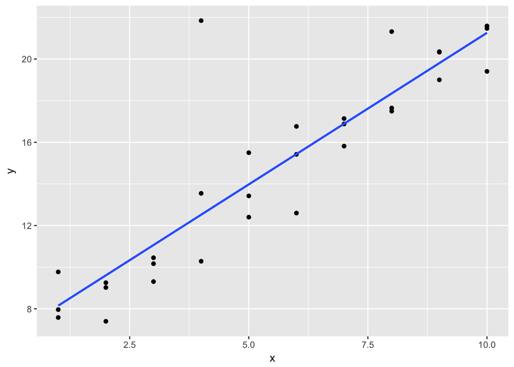

```r
ggplot(sim1a, aes(x=x, y=y)) + geom_point() + geom_smooth(method=lm, se=FALSE)
```